# Analysis of Employee attrition

Zeralm

10/14/2021

The following code generates descriptive statistics and basic plots, cleans data and performs some hypothesis tests. Finally three Survival Analysis models are applied in order to ascertain the predictors of employee turnover.

The data is real, provided by Edward Babushkin - https://edwvb.blogspot.com/2017/10/employee-turnover-how-to-predict-individual-risks-of-quitting.html?m=1

# Cleaning

```
##       stag             event     gender       age               industry
##  Min.   :  0.3942   Quit  :553   m:275   Min.   :18.00   Retail     :280
##  1st Qu.: 11.7125   Stayed:554   f:832   1st Qu.:25.00   manufacture:143
##  Median : 24.4107                        Median :30.00   IT         :122
##  Mean   : 36.6903                        Mean   :31.03   Banks      :111
##  3rd Qu.: 51.4497                        3rd Qu.:36.00   etc        : 92
##  Max.   :179.4497                        Max.   :58.00   Consult    : 73
##                                                          (Other)    :286
##                profession         traffic
##  HR                 :739   youjs      :311
##  IT                 : 74   empjs      :247
##  Sales              : 65   rabrecNErab:206
##  etc                : 37   friends    :115
##  Marketing          : 30   referal    : 94
##  BusinessDevelopment: 27   KA         : 65
##  (Other)            :135   (Other)    : 69
```

```
##      coach     head_gender  greywage     way       extraversion
##  no     :667   f:536       white:984   bus :668   Min.   : 1.000
##  yes    :130   m:571       grey :123   car :325   1st Qu.: 4.600
##  my head:310                           foot:114   Median : 5.400
##                                                   Mean   : 5.578
##                                                   3rd Qu.: 7.000
##                                                   Max.   :10.000
##     independ      selfcontrol        anxiety          novator
##  Min.   : 1.00   Min.   : 1.000   Min.   : 1.700   Min.   : 1.000
##  1st Qu.: 4.10   1st Qu.: 4.100   1st Qu.: 4.800   1st Qu.: 4.400
##  Median : 5.50   Median : 5.700   Median : 5.600   Median : 6.000
##  Mean   : 5.47   Mean   : 5.616   Mean   : 5.674   Mean   : 5.878
##  3rd Qu.: 6.90   3rd Qu.: 7.200   3rd Qu.: 7.100   3rd Qu.: 7.500
##  Max.   :10.00   Max.   :10.000   Max.   :10.000   Max.   :10.000
```

# Visualization

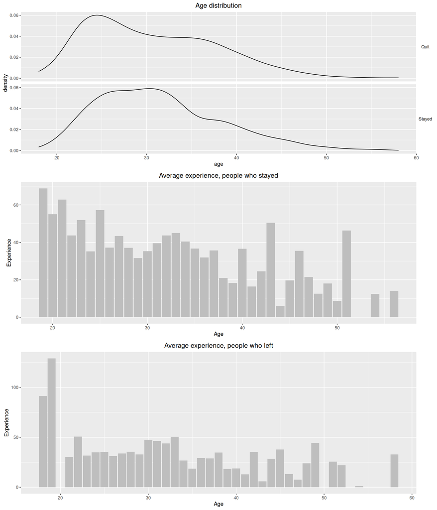

```r
# -

# Age distr
graph1 <- ggplot(data, mapping = aes(x = age)) + geom_density() + facet_grid(event~.) +
  labs(title = "Age distribution") +
  theme(plot.title = element_text(hjust = 0.5), strip.text.y = element_text(angle = 0), strip.background = element_rect(fill = "white"))

# experience vs age
graph2.1 <- data[data$event == "Stayed",] %>% group_by(age) %>% summarize(mean(stag)) %>%
  rename(avg_stag = `mean(stag)`) %>%
  ggplot(mapping = aes(x = age, y = avg_stag)) + geom_col(fill = "Grey")  +
  labs(title = "Average experience, people who stayed", x = "Age", y = "Experience") +
  theme(plot.title = element_text(hjust = 0.5))

graph2.2 <- data[data$event == "Quit",] %>% group_by(age) %>% summarize(mean(stag)) %>%
  rename(avg_stag = `mean(stag)`) %>%
  ggplot(mapping = aes(x = age, y = avg_stag)) + geom_col(fill = "Grey")  +
  labs(title = "Average experience, people who left", x = "Age", y = "Experience") +
  theme(plot.title = element_text(hjust = 0.5))

graph3 <- melt(data %>% select(event,(extraversion:novator))) %>%
  ggplot(mapping = aes(x = variable, y = value, fill = event), size = 10) +
  stat_summary(fun = mean, position = "dodge" ,geom = "bar", color = "black") + labs(title = "Big 5 scores") +
  theme(plot.title = element_text(hjust = 0.5), axis.title.x = element_text(color = "white"), legend.title = element_blank(), legend.margin = margin(3,1,3,6)) +
  scale_fill_brewer(palette = "Greys")

graph4 <- data %>% ggplot(mapping = aes(x = age, event)) + geom_boxplot(aes(fill = event), color = "black", show.legend = FALSE) +
  coord_flip() + labs(title = "Age distribution", x = "Age") +
  theme(plot.title = element_text(hjust = 0.5), axis.title.x = element_blank(), legend.title = element_blank()) +
  scale_fill_brewer(palette = "Greys")

graph5 <- data %>% ggplot(mapping = aes(x = industry)) +
  geom_bar(aes(fill = event), color = "black", position = "dodge", show.legend = FALSE) +
  theme(plot.title = element_text(hjust = 0.5) ,axis.title.y = element_blank(), legend.title = element_blank()) +
  labs(title = "Number of people per industry", x = "") + scale_x_discrete(guide = guide_axis(n.dodge = 3)) +
  scale_fill_brewer(palette = "Greys")

graph6 <- data %>% ggplot(mapping = aes(x = profession)) +
  geom_bar(aes(fill = event), color = "black", position = "dodge", show.legend = FALSE) +
  theme(plot.title = element_text(hjust = 0.5), axis.title.y = element_blank(), legend.title = element_blank()) +
  labs(title = "Number of people per profession", x = "") + scale_x_discrete(guide = guide_axis(n.dodge = 3)) +
  scale_fill_brewer(palette = "Greys")

graph7 <- data %>% ggplot(mapping = aes(x = way)) +
  geom_bar(aes(fill = event), color = "black", position = "dodge", show.legend = FALSE) +
  theme(plot.title = element_text(hjust = 0.5), axis.title.y = element_blank(), legend.title = element_blank()) +
  labs(title = "Commute choice", x = "") + scale_fill_brewer(palette = "Greys")

graph8 <- melt(data %>% select(event, age, stag)) %>% ggplot(mapping = aes(x = variable, y = value, fill = event)) +
  stat_summary(fun = mean, color = "black", position = "dodge", geom = "bar", show.legend = FALSE) + labs(title = "Average age and experience", x = "", y = "Value") +
  theme(plot.title = element_text(hjust = 0.5), legend.title = element_blank()) +
  scale_fill_brewer(palette = "Greys")

ggarrange(graph1, graph2.1, graph2.2, nrow = 3, widths = c(2, c(1, 1)))
```

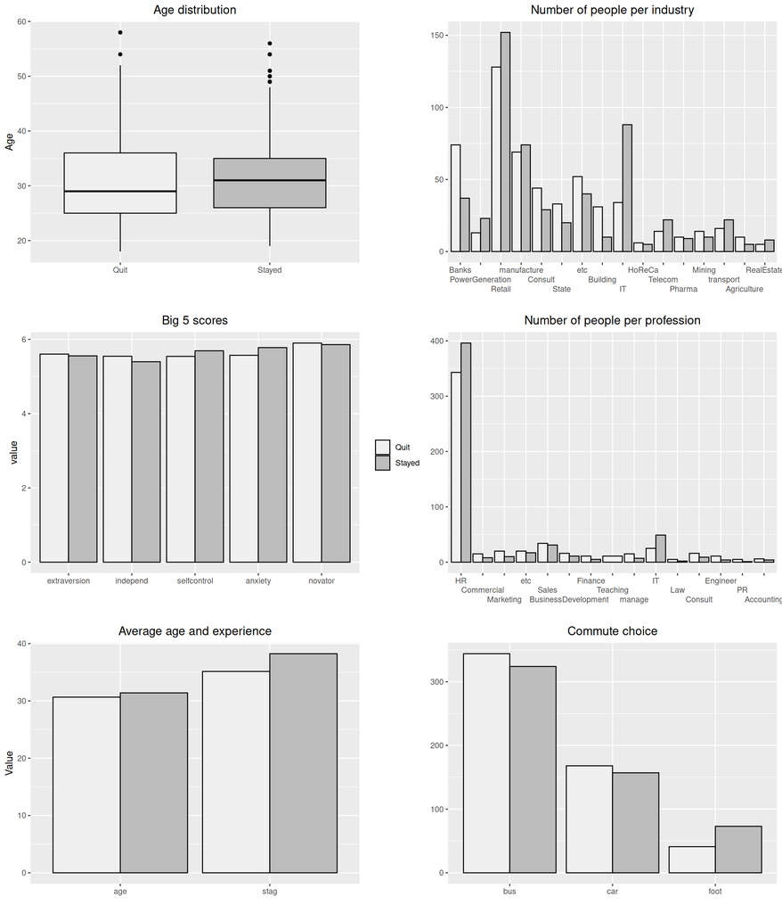

```r
ggarrange(graph4 ,graph5, graph3, graph6, graph8, graph7)
```

# Statistical tests

```r
# - STATISTICAL TESTS

# H0: B1 = B2 = B3 = B4 = B5 = 0
# H1: B1 != 0 or B2 != 0, or both, or..., or all

big5_event <- data[data$event == "Quit",  names(data) %in% c("independ", "anxiety", "extraversion", "novator", "selfcontrol")]
big5_no_event <- data[data$event == "Stayed",  names(data ) %in% c("independ", "anxiety", "extraversion", "novator", "selfcontrol")]
big5.pvalue <- HotellingsT2Test(big5_event, big5_no_event)$p.value

# H0: p = 0.5 (probability of leaving)
# H1: p < 0.5

male_event = dim(data[(data$event == "Quit") & (data$gender == "m"),  "gender"])[1]
len_male_evth = dim(data[data$gender == "m", "gender"])[1]
male.pvalue <- pbinom(male_event, len_male_evth, 0.5) #Cannot reject


female_event = dim(data[(data$event == "Quit") & (data$gender == "f"),  "gender"])[1]
len_female_evth = dim(data[data$gender == "f","gender"])[1]
female.pvalue <- pbinom(female_event, len_female_evth, 0.5) #Cannot reject

head_male_event = dim(data[(data$event == "Quit") & (data$head_gender == "m"),  "head_gender"])[1]
len_head_male_evth = dim(data[data$head_gender == "m","head_gender"])[1]
headmale.pvalue <- pbinom(head_male_event, len_head_male_evth, 0.5) #Cannot reject

head_female_event = dim(data[(data$event == "Quit") & (data$head_gender == "f"),  "head_gender"])[1]
len_head_female_evth = dim(data[data$head_gender == "f","head_gender"])[1]
headfemale.pvalue <- pbinom(head_female_event, len_head_female_evth, 0.5) #Cannot reject

# H0: B1 = 0
# H1: B1 != 0

age_event = data[data$event == "Quit", "age"]
age_no_event = data[data$event == "Stayed", "age"]
age.pvalue <- t.test(age_event, age_no_event)$p.value #Cannot reject

stag_event = data[data$event == "Quit", "stag"]
stag_no_event = data[data$event == "Stayed", "stag"]
stag.pvalue <- t.test(stag_event, stag_no_event)$p.value #Cannot reject


pvalues = c(big5.pvalue, male.pvalue, female.pvalue, headmale.pvalue, headfemale.pvalue, age.pvalue, stag.pvalue)
testnames = c("Hoteling's t-test: Big 5" , "binomial test: males", "binomial test: females", "binomial test: head males", "binomial test: head females", "t-test: age", "t-test: stag")
significant_at_0.05 = pvalues < 0.05

data.frame(testnames,pvalues, significant_at_0.05)
```

| testnames | pvalues | significant_at_0.05 |
| --- | --- | --- |
| Hoteling's t-test: Big 5 | 0.21493521 | FALSE |
| binomial test: males | 0.35878148 | FALSE |
| binomial test: females | 0.59586499 | FALSE |
| binomial test: head males | 0.82138355 | FALSE |
| binomial test: head females | 0.18219375 | FALSE |
| t-test: age | 0.07625558 | FALSE |
| t-test: stag | 0.13239632 | FALSE |

# Survival analysis

Why survival analysis, instead of logistic regression?

- The coefficients on tenure would not be useful. This variable is mismanaged in logistic regressions: we don’t want to predict the turnover of current employees. We want to predict the turnover of future employees, so current tenure is irrelevant and unactionable.
- Survival analysis allows you to be precise and detect breakpoints and trends.
- If you actually want to find breakpoints or changes in slope (splines), you should probably plot the dataset like a distribution of tenure-survival. That would already resemble survival analysis, but in a much less precise way.
- It will be more accurate answering our practical questions on turnover.

```r
newdat <- read_csv("data/turnover-data-set_utf.csv", show_col_types = FALSE,
                 col_types = "dififffffffddddd")
newdat <- newdat[!duplicated(newdat) & !apply(is.na(newdat), 1, any),]

train <- newdat[sample(nrow(newdat), nrow(newdat) * 0.7), ]
test <- newdat[setdiff(seq_len(nrow(newdat)), sample(nrow(newdat), nrow(newdat) * 0.7)), ]
```

## Kaplan-Meier model

The simplest possible model and our baseline. It takes into account a single independent variable, namely, tenure. However, we can generate many survival curves for every possible realization of another variable. This already provides useful insight.

```r
objSurv <- with(train, Surv(stag, event))
survfit(objSurv ~ 1)
```

```
## Call: survfit(formula = objSurv ~ 1)
##
##        n events median 0.95LCL 0.95UCL
## [1,] 774    384   50.7    45.3    56.8
```

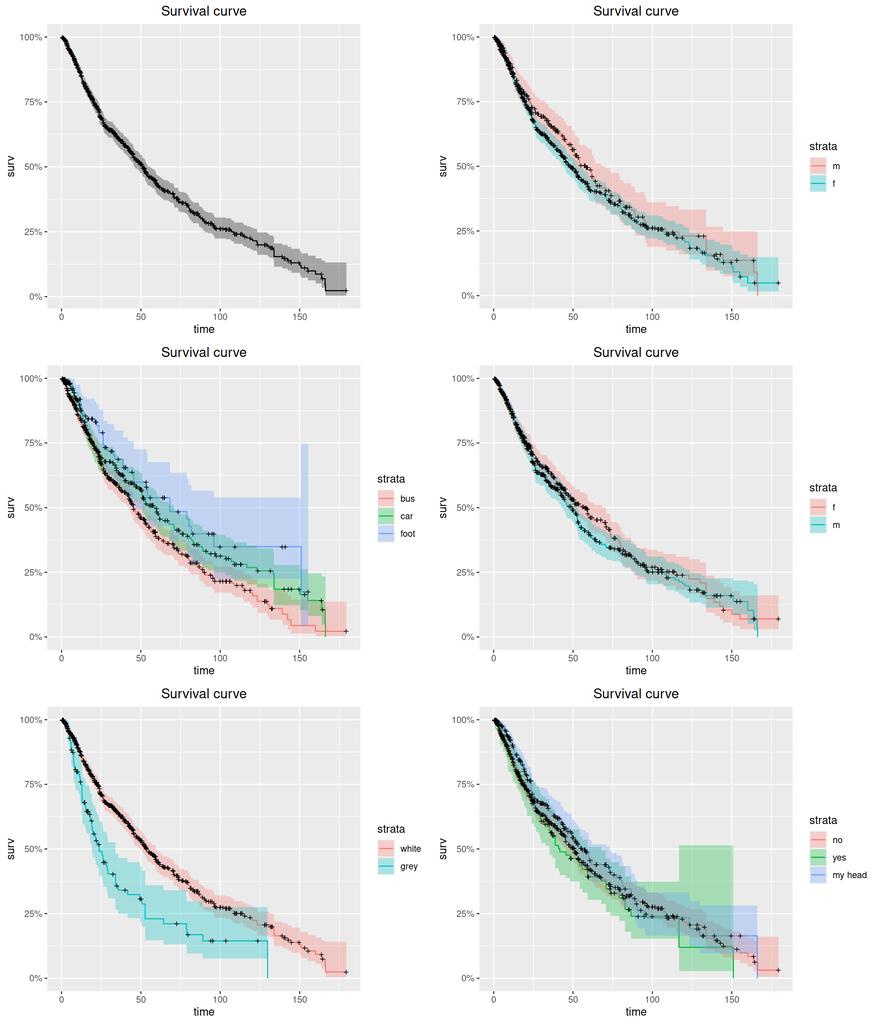

```r
survplot1 <- autoplot(survfit(Surv(stag, event) ~ 1, data = newdat)) + labs(title = "Survival curve") + theme(plot.title = element_text(hjust = 0.5))
survplot2 <- autoplot(survfit(Surv(stag, event) ~ gender, data = newdat)) + labs(title = "Survival curve") + theme(plot.title = element_text(hjust = 0.5))
survplot3 <- autoplot(survfit(Surv(stag, event) ~ way, data = newdat)) + labs(title = "Survival curve") + theme(plot.title = element_text(hjust = 0.5))
survplot4 <- autoplot(survfit(Surv(stag, event) ~ head_gender, data = newdat)) + labs(title = "Survival curve") + theme(plot.title = element_text(hjust = 0.5))
survplot5 <- autoplot(survfit(Surv(stag, event) ~ greywage, data = newdat)) + labs(title = "Survival curve") + theme(plot.title = element_text(hjust = 0.5))
survplot6 <- autoplot(survfit(Surv(stag, event) ~ coach, data = newdat)) + labs(title = "Survival curve") + theme(plot.title = element_text(hjust = 0.5))

ggarrange(survplot1, survplot2, survplot3, survplot4, survplot5, survplot6)
```

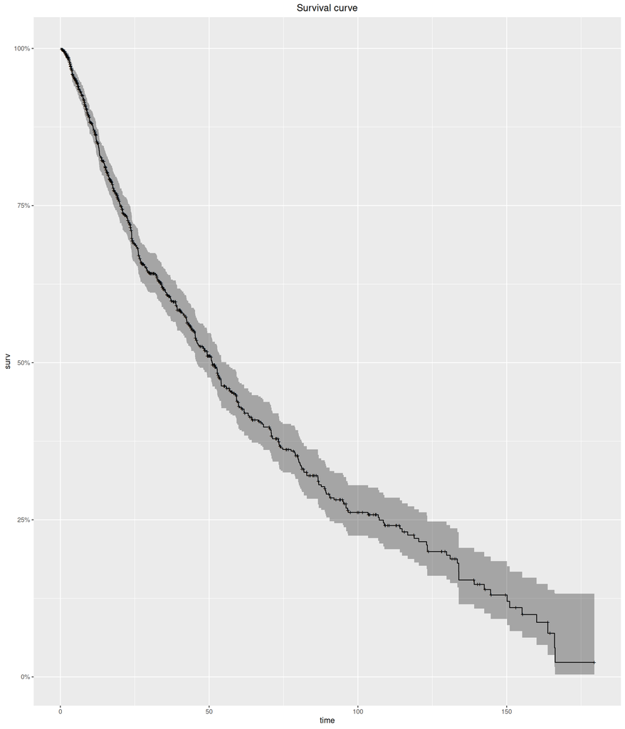

```r
survplot7 <- autoplot(survfit(Surv(stag, event) ~ 1 ,data = newdat)) + labs(title = "Survival curve") + theme(plot.title = element_text(hjust = 0.5))

survplot7
```

## Cox model

Fitting cox model that accounts for all covariates but assumes them to be stable over time:

```r
cox <- coxph(Surv(stag, event) ~ 1 +  gender + age + industry +
               + greywage + way + extraversion + independ + selfcontrol +
               anxiety + novator+ coach + head_gender, data = newdat)

summary(cox)
```

```
## Call:
## coxph(formula = Surv(stag, event) ~ 1 + gender + age + industry +
##     +greywage + way + extraversion + independ + selfcontrol +
##     anxiety + novator + coach + head_gender, data = newdat)
##
##   n= 1107, number of events= 553
##
##                              coef exp(coef)  se(coef)      z Pr(>|z|)
## genderf                  0.010213  1.010265  0.111203  0.092 0.926824
## age                      0.023624  1.023905  0.006741  3.505 0.000457 ***
## industryPowerGeneration -0.591848  0.553304  0.306951 -1.928 0.053836 .
## industryRetail          -0.642597  0.525925  0.149685 -4.293 1.76e-05 ***
## industrymanufacture     -0.526270  0.590804  0.173383 -3.035 0.002403 **
## industryConsult         -0.012943  0.987140  0.197223 -0.066 0.947675
## industryState           -0.220205  0.802355  0.215093 -1.024 0.305947
## industryetc             -0.177630  0.837252  0.185944 -0.955 0.339433
## industryBuilding         0.046920  1.048039  0.220251  0.213 0.831302
## industryIT              -0.884081  0.413094  0.211747 -4.175 2.98e-05 ***
## industryHoReCa          -0.341230  0.710895  0.431231 -0.791 0.428773
## industryTelecom         -0.925861  0.396190  0.295136 -3.137 0.001707 **
## industryPharma          -0.555370  0.573860  0.348911 -1.592 0.111446
## industryMining          -0.244900  0.782783  0.298681 -0.820 0.412250
## industrytransport       -0.405938  0.666351  0.279887 -1.450 0.146957
## industryAgriculture      0.527673  1.694984  0.343511  1.536 0.124510
## industryRealEstate      -1.154774  0.315129  0.475330 -2.429 0.015123 *
## greywagegrey             0.624656  1.867602  0.133713  4.672 2.99e-06 ***
## waycar                  -0.211375  0.809470  0.100122 -2.111 0.034757 *
## wayfoot                 -0.464456  0.628477  0.171858 -2.703 0.006881 **
## extraversion             0.030479  1.030948  0.034828  0.875 0.381510
## independ                -0.012817  0.987265  0.035085 -0.365 0.714882
## selfcontrol             -0.036709  0.963957  0.035258 -1.041 0.297812
## anxiety                 -0.032466  0.968055  0.033551 -0.968 0.333219
## novator                  0.009905  1.009954  0.030170  0.328 0.742675
## coachyes                 0.167281  1.182087  0.138525  1.208 0.227206
## coachmy head            -0.001242  0.998759  0.107407 -0.012 0.990773
## head_genderm             0.017668  1.017825  0.094271  0.187 0.851334
## ---
## Signif. codes:  0 '***' 0.001 '**' 0.01 '*' 0.05 '.' 0.1 ' ' 1
##
##                         exp(coef) exp(-coef) lower .95 upper .95
```

[output cut: 18 more lines]

```
## waycar                     0.8095     1.2354    0.6652    0.9850
## wayfoot                    0.6285     1.5911    0.4487    0.8802
## extraversion               1.0309     0.9700    0.9629    1.1038
## independ                   0.9873     1.0129    0.9217    1.0575
## selfcontrol                0.9640     1.0374    0.8996    1.0329
## anxiety                    0.9681     1.0330    0.9064    1.0339
## novator                    1.0100     0.9901    0.9520    1.0715
## coachyes                   1.1821     0.8460    0.9010    1.5508
## coachmy head               0.9988     1.0012    0.8092    1.2328
## head_genderm               1.0178     0.9825    0.8461    1.2244
##
## Concordance= 0.629  (se = 0.014 )
## Likelihood ratio test= 115.3  on 28 df,   p=1e-12
## Wald test            = 120.3  on 28 df,   p=2e-13
## Score (logrank) test = 124.9  on 28 df,   p=3e-14
```

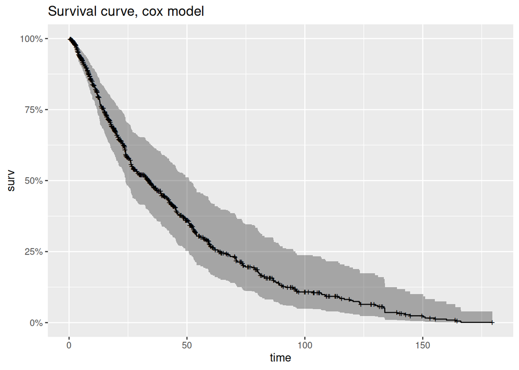

```r
autoplot(survfit(cox)) + labs(title = "Survival curve, cox model")
```

## Aalen model

This model doesn’t assume assume coefficients are stable

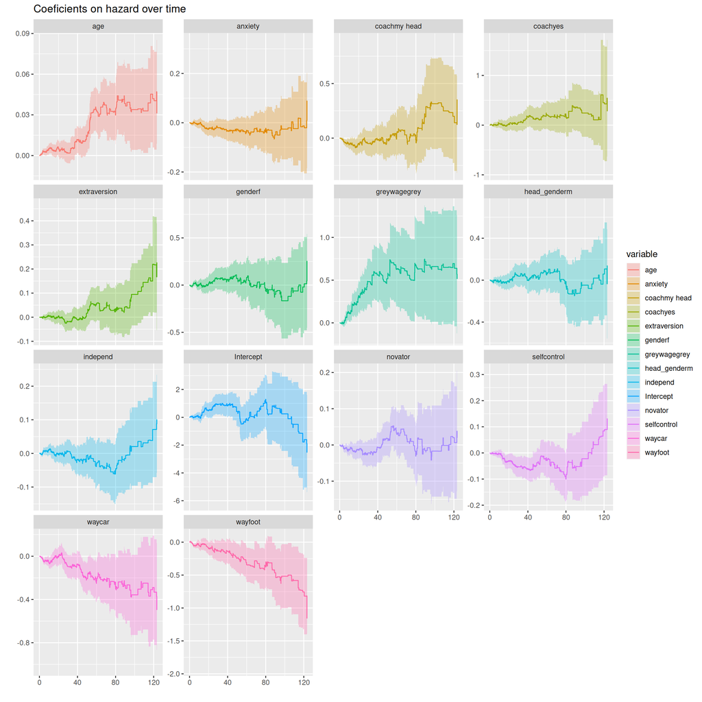

```r
# References:
# Cox DR. A note on the graphical analysis of survival data. Biometrika. 1979;66:188–190
# Kaplan EL, Meier P. Nonparametric estimation from incomplete observations. J Am Stat Assoc. 1958;53:457–481
aa_fit = aareg(Surv(stag, event) ~ 1 +  gender + age +
                  greywage + way + extraversion + independ + selfcontrol +
                  anxiety + novator + coach + head_gender, data = newdat)

autoplot(aa_fit) + labs(title = "Coeficients on hazard over time")
```

Some hazard effects clearly vary over time (a(t) - XB(t)), so the cox implementation should be taken with a grain of salt.  
Grey wage is a predictor of quitting, and going to work by foot is a negative predictor of quitting.  
Age is a predictor of quitting on longer tenures. Higher conscientiousness is associated to lower turnover in the first years.

Practical recommendation: hire in surroundings, offer help in accommodation.  
People with longer tenure and age are at risk. Maybe senior promotion is not encouraged, or salary for more senior roles is not competitive, so people with more experience are more prone to leave when they acquire seniority.  
Look for weak signals of conscientiousness when hiring (psychometric tests are likely to be tricked to favor conscientiousness).